# HW 04

## Set Up

```r
library(tidyverse)
```

## Question 1

```r
nfl_salaries <- read_csv("https://raw.githubusercontent.com/vaiseys/dav-course/main/Data/nfl_salaries.csv")
glimpse(nfl_salaries)
```

```
Rows: 800
Columns: 11
$ year                <dbl> 2011, 2011, 2011, 2011, 2011, 2011, 2011, 2011, 20…
$ Cornerback          <dbl> 11265916, 11000000, 10000000, 10000000, 10000000, …
$ `Defensive Lineman` <dbl> 17818000, 16200000, 12476000, 11904706, 11762782, …
$ Linebacker          <dbl> 16420000, 15623000, 11825000, 10083333, 10020000, …
$ `Offensive Lineman` <dbl> 15960000, 12800000, 11767500, 10358200, 10000000, …
$ Quarterback         <dbl> 17228125, 16000000, 14400000, 14100000, 13510000, …
$ `Running Back`      <dbl> 12955000, 10873833, 9479000, 7700000, 7500000, 703…
$ Safety              <dbl> 8871428, 8787500, 8282500, 8000000, 7804333, 76527…
$ `Special Teamer`    <dbl> 4300000, 3725000, 3556176, 3500000, 3250000, 32250…
$ `Tight End`         <dbl> 8734375, 8591000, 8290000, 7723333, 6974666, 61333…
$ `Wide Receiver`     <dbl> 16250000, 14175000, 11424000, 11415000, 10800000, …
```

## Question 2

Reshape it so that every row tells you the salary associated with a position each year. Your new dataset should have three columns: `year`, `position`, `salary`.

```r
tidy_nfl_salaries <- nfl_salaries |>
  pivot_longer(cols = c(2:11),
               names_to = "Position",
               values_to = "Salary")
tidy_nfl_salaries
```

```
# A tibble: 8,000 × 3
    year Position            Salary
   <dbl> <chr>                <dbl>
 1  2011 Cornerback        11265916
 2  2011 Defensive Lineman 17818000
 3  2011 Linebacker        16420000
 4  2011 Offensive Lineman 15960000
 5  2011 Quarterback       17228125
 6  2011 Running Back      12955000
 7  2011 Safety             8871428
 8  2011 Special Teamer     4300000
 9  2011 Tight End          8734375
10  2011 Wide Receiver     16250000
# ℹ 7,990 more rows
```

## Question 3

Filter your newly created dataset so that it only contains quarterbacks. Then, make a histogram where salary is in the x-axis. Then use `facet_wrap` to get the histogram for each `year`.

```r
tidy_quarterbacks <- tidy_nfl_salaries %>% filter(Position == "Quarterback")
```

```r
tidy_quarterbacks <- tidy_quarterbacks |>
  mutate(new_salary = Salary / 1000000)
```

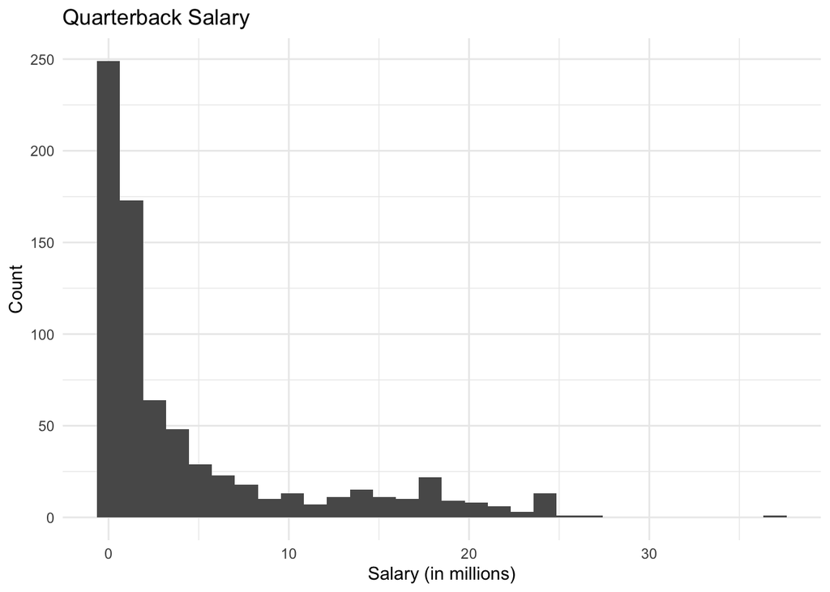

```r
ggplot(tidy_quarterbacks,
       aes(x = new_salary)) +
  geom_histogram()+
  theme_minimal()+
  labs(x = "Salary (in millions)", y = "Count", title = "Quarterback Salary")
```

Then use `facet_wrap` to get the histogram for each `year`.

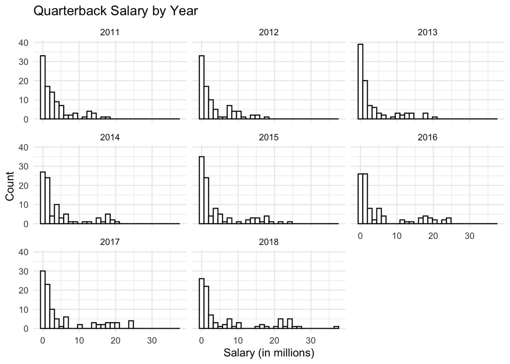

```r
 ggplot(tidy_quarterbacks,
       aes(x = new_salary)) +
  geom_histogram(colour = "black",
                 fill="white")+
  facet_wrap(~year)+
  theme_minimal()+
  labs(x = "Salary (in millions)", y = "Count", title = "Quarterback Salary by Year")
```

**What patterns do you notice?**

There is a higher count of Quarterbacks making less than 1 million. As the years go on, there are more outliers of quarterbacks with higher and higher salaries.

## Question 4

Let’s calculate the average salary for each position, each year. Create a new dataset that contains the average salary for each position each year. To do this, you will need the `group_by` and `summarize` combo.

```r
salary_position <- tidy_nfl_salaries |>
  group_by(Position, year) |>
  summarize(avg_salary = mean(Salary, na.rm = TRUE)) |>
  ungroup()
salary_position
```

```
# A tibble: 80 × 3
   Position           year avg_salary
   <chr>             <dbl>      <dbl>
 1 Cornerback         2011   3037766.
 2 Cornerback         2012   3132916.
 3 Cornerback         2013   2901798.
 4 Cornerback         2014   3038278.
 5 Cornerback         2015   3758543.
 6 Cornerback         2016   4201470.
 7 Cornerback         2017   4125692.
 8 Cornerback         2018   4659704.
 9 Defensive Lineman  2011   4306995.
10 Defensive Lineman  2012   4693730.
# ℹ 70 more rows
```

## Question 5

Make a linegraph that traces the evolution of each position’s average salary across the years. You can use use different strategies to distinguish between positions - color or facets for example. What is important is that you see each position’s trajectory clearly and that they are comparable.

```r
salary_position <- salary_position |>
    mutate(avg_salary = avg_salary / 1000000)
```

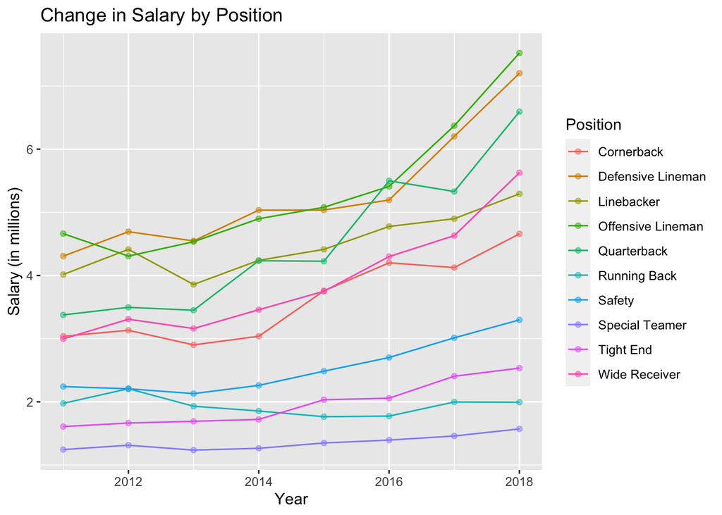

```r
ggplot(salary_position,
       aes(x = year,
           y = avg_salary,
           label = Position,
           colour = Position)) +
  geom_line()+
  geom_point(alpha=.5)+
  labs(y = "Salary (in millions)", x = "Year", title = "Change in Salary by Position")
```

**Describe at least two trends that are apparent to you.**

The offensive and defensive lineman seem to have steeper salary increases in 2016 through 2018. Throughout all the years, the special team position has the lowest salary.